# HW3

Homework 3

Problem #1

1a) Which algorithm makes the fewest mistakes?

[output not shown]

1b) Which algorithm is better for the zoo? Explain.

```
Since, for the zoo, it would be a big deal to misidentify bird as person, NA would be a better algorithm for it. It misidentify less birds as person than NN algorithm.
```

1c) During the pandemic the number of visitors plummets, and it is only the zoo keeper visiting. So instead of 52% of the photos taken at the aviary door being people, it is now only 1%. Make new truth tables for both algorithms.

In order to make our calculation make sense, we will be looking at 1000 photos rather than 100.

NN Algorithm:

```python
import pandas as pd
import numpy as np
bird = 1000 * 0.99
ppl = 1000 * 0.01
birdT = np.round(bird * (45/48))
birdF = bird - birdT
pplT = np.round(ppl * (47/52))
pplF = ppl - pplT
table = pd.DataFrame([[birdT, pplF],[birdF, pplT]],index = ['Test Good','Test Bad'], columns=['True T', 'Bad T'])
table
```

|  | True T | Bad T |
| --- | --- | --- |
| Test Good | 928.0 | 1.0 |
| Test Bad | 62.0 | 9.0 |

NA Algorithm:

```python
bird = 1000 * 0.99
ppl = 1000 * 0.01
birdT = np.round(bird * (47/48))
birdF = bird - birdT
pplT = np.round(ppl * (42/52))
pplF = ppl - pplT
table = pd.DataFrame([[birdT, pplF],[birdF, pplT]],index = ['Test Good','Test Bad'], columns=['True T', 'Bad T'])
table
```

|  | True T | Bad T |
| --- | --- | --- |
| Test Good | 969.0 | 2.0 |
| Test Bad | 21.0 | 8.0 |

Problem #2

2a) What is the pdf of the sum of two identical exponential distributions?

The pdf of sum of two identical exponential distributions is equal to λXe^-λx, which would be an Erlang distribution.

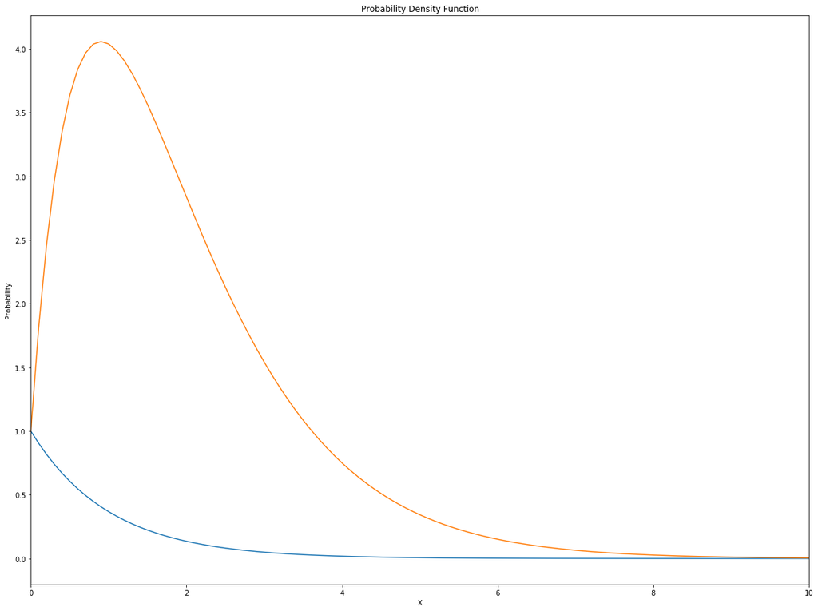

```python
import numpy as np
import matplotlib
import matplotlib.pyplot as plt
import scipy
from scipy import stats
from scipy import signal
#this sets the size of the plot to something useful
plt.rcParams["figure.figsize"] = (20,15)

fig,  ax = plt.subplots(1, 1)
plt.xlim(0,10)
x = np.linspace(0,50,500)
expo = stats.expon.pdf(x)
x2 = np.linspace(0,100,999)
conv = signal.convolve(expo,expo)
ax.plot(x,expo)
ax.plot(x2,conv)
plt.title("Probability Density Function")
plt.xlabel("X")
plt.ylabel("Probability")
plt.show()
```

2b) What is the pdf of the ratio of two zero-mean unity variance normal distributions 𝑋1/𝑋2 ?

The pdf of the ratio of two zero-mean unity variance normal distributions is called Cauchy distribution.

First, when we look up online for ratio of two differet distribution, we would find articles abour Ratio distribution. We will find out that the ratio of two independent random distribution like Z = X/Y is called a ratio distribution, and when the two random distribution is two normally distributed random variables, it is called Cauchy distribution.

2c) So far we have looked at 1D probability distributions, but it is possible to have a multi-dimensional vector distribution. A simple first introduction is the 2D Guassian; it looks like a smeared spot. Mathematically this is given by 𝑋𝑖̂ +𝑌𝑗̂ where both 𝑋 and 𝑌 are drawn from 1D Gaussian distributions. If I measure the amplitude of this vector, what is its pdf? (Hint, the amplitude is always positive.)